```markdown
---
title: "Guide to Social Media Analysis Functions"
author: "A. Rahman"
date: "2024-04-15"
output: html_document
---
```

# Introduction

This document is a comprehensive guide that demonstrates the usage of functions provided by the SocialNetAnalyser package for social media data analysis. The guide covers:

- How to load and inspect the social media data.
- Methods to calculate basic engagement metrics.
- Techniques to visualize engagement trends and posting trends over time.
- Steps to perform a dummy sentiment analysis.

For the source code, please visit the [SocialNetAnalyser - GitHub repository](https://github.com/rahmanumar21/SocialNetAnalyser). For more details on using R Markdown, see [R Markdown’s official site](http://rmarkdown.rstudio.com).

# Preliminaries

Before proceeding, we need to set up our environment by loading the necessary functions and data.

## Load Required Functions and Data

```r
# Loading functions from the SocialNetAnalyser package
source("~/SocialNetAnalyser/R/main.R")
```

```
##   total_posts total_likes total_comments total_shares average_engagement_rate
## 1          29        1670            142           90                65.58621
```

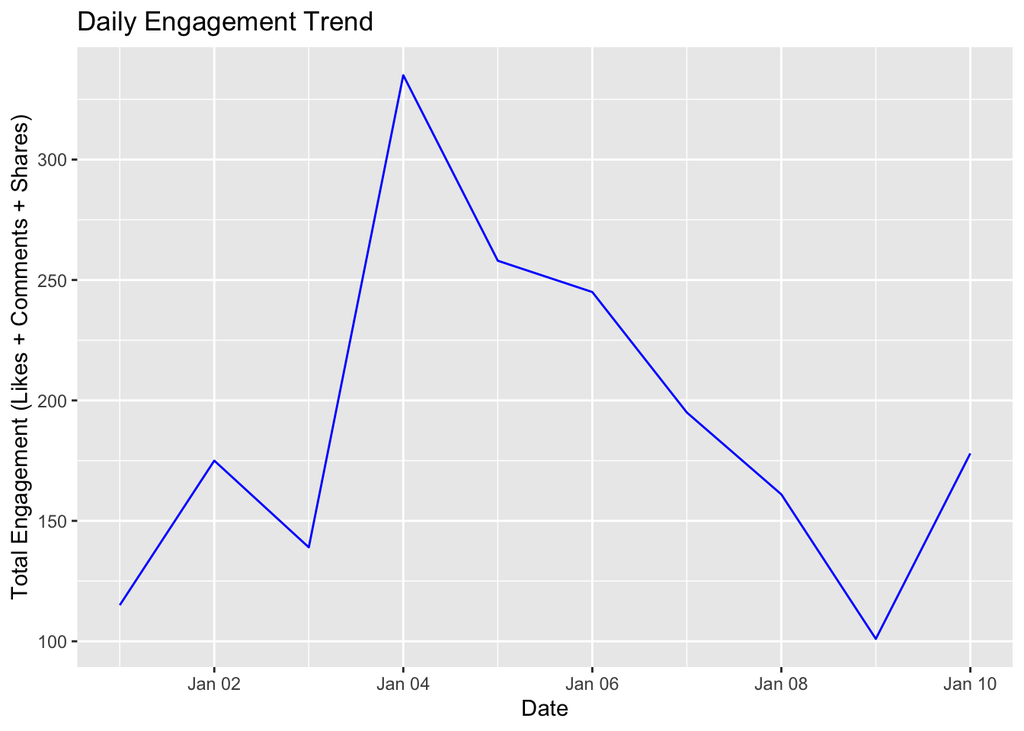

```
##          date sentiment
## 1  2022-01-01  Positive
## 2  2022-01-02  Negative
## 3  2022-01-03   Neutral
## 4  2022-01-04  Positive
## 5  2022-01-05  Negative
## 6  2022-01-06  Positive
## 7  2022-01-07  Negative
## 8  2022-01-08   Neutral
## 9  2022-01-09  Positive
## 10 2022-01-10  Negative
```

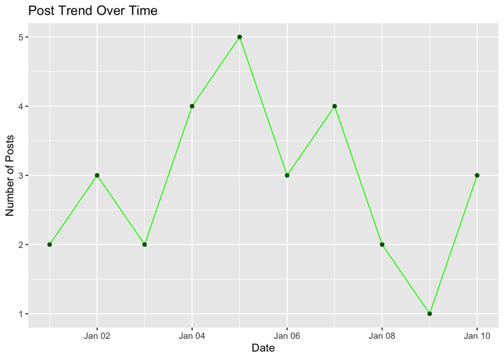

```r
# Loading the dataset
load("data/social_data.RData")
```

## Inspect Data Structure

```r
# It's important to understand the structure of our data before analysis
str(social_data)
```

```
## 'data.frame':    10 obs. of  5 variables:
##  $ date    : Date, format: "2022-01-01" "2022-01-02" ...
##  $ posts   : num  2 3 2 4 5 3 4 2 1 3
##  $ likes   : num  100 150 120 300 230 200 180 140 90 160
##  $ comments: num  10 15 12 20 18 25 10 14 8 10
##  $ shares  : num  5 10 7 15 10 20 5 7 3 8
```

# Data Analysis

With our data loaded and understood, we can now proceed to analyze it using various functions.

## Calculate Metrics

Calculate and summarize the basic engagement metrics from the social media data.

```r
metrics_table <- calculate_metrics(social_data)
metrics_table
```

```
##   total_posts total_likes total_comments total_shares average_engagement_rate
## 1          29        1670            142           90                65.58621
```

## Engagement Trends Visualization

Visualize the engagement trends over time using the number of likes, comments, and shares.

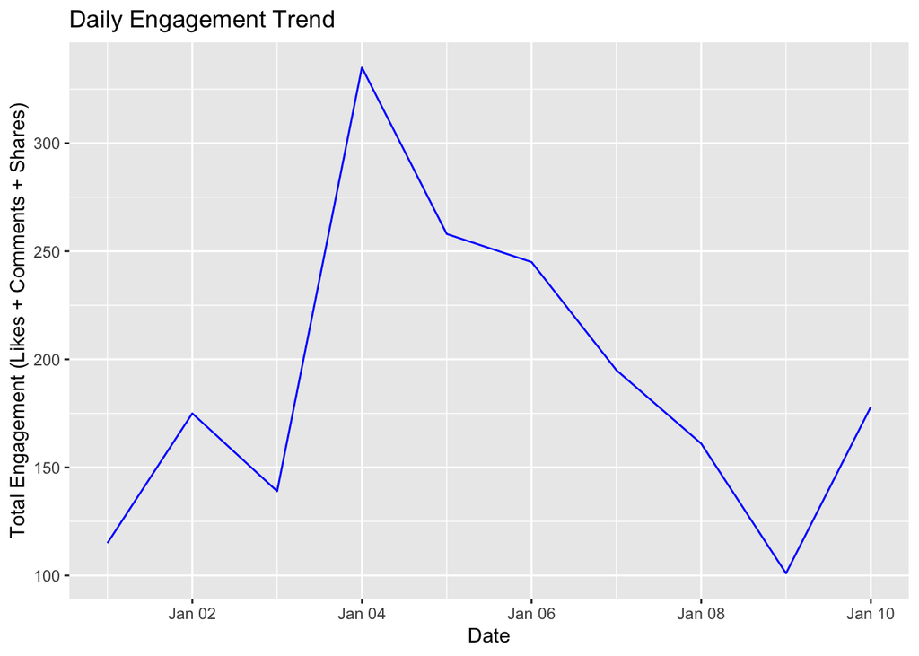

```r
engagement_plot <- plot_engagement(social_data)
print(engagement_plot)
```

## Sentiment Analysis

Assign a random sentiment score to each social media post and display the results.

```r
sentiment_results <- analyse_sentiment(social_data)
print(sentiment_results)
```

```
##          date sentiment
## 1  2022-01-01  Positive
## 2  2022-01-02  Positive
## 3  2022-01-03  Positive
## 4  2022-01-04  Positive
## 5  2022-01-05  Positive
## 6  2022-01-06  Positive
## 7  2022-01-07  Positive
## 8  2022-01-08  Positive
## 9  2022-01-09  Positive
## 10 2022-01-10  Positive
```

## Posting Trends Visualization

Plot the trends showing the number of posts over time.

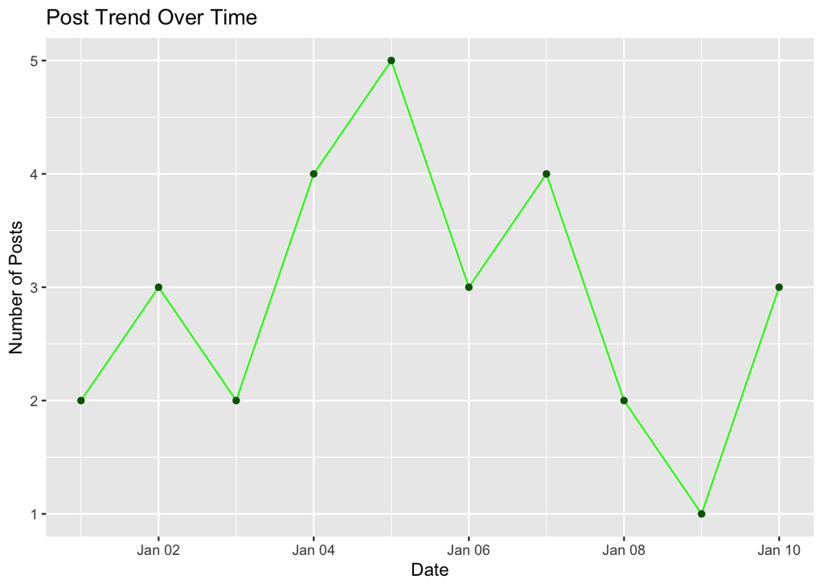

```r
post_trend_plot <- plot_post_trends(social_data)
print(post_trend_plot)
```

# Conclusion

The SocialNetAnalyser package provides a suite of tools that makes the analysis of social media data both accessible and insightful. By employing these functions, we can derive meaningful patterns and metrics from social data.